# Workflow and tips on data wrangling

R for Data Science

## Some notes on dplyr

The `dplyr` package is one of the packages contained in the `tidyverse` collection. It specializes in helping us wrangle data sets– select subsets, arrange data, create new variables, etc.

As you may have noticed in the reading, every `dplyr` function follows a similar format:

- The first argument is the name of the data frame
- The subsequent arguments (separated by commas) tell R what to do to that data. Because we’ve already told R what data set we are working with, we can refer to variable names directly (without the `$` we learned about in week 1)
- Each function returns a data frame. That means that if you just type the function into your console, the result will try to print the ENTIRE resulting data frame. You may want to consider saving your results to a new data frame instead (e.g. `new_data <- select(old_data, var1, var2, var3)`). More on that next…

## Workflow with dplyr

When working with data wrangling and transformation, there are two general purposes:

- **Change our data set for use later.** We may want to create subsets (filter) or new variables (mutate) to use in later visualizations or analyses. In this case, it’s very important to make sure we save the results of our data wrangling to keep for later use.
- **Display summaries or unusual cases.** We may just want to highlight the mean and standard deviation in each sub-group. Or we may want to print out the top five values. In this case, our purpose is to inform our audience, but we don’t necessarily need to save the results of our work for later. Printing the output will suffice.

#### Change data for later use

Often when we create new variables or subsets, we are doing so with the intent of graphing or modeling that data later. In this case, it’s important to save the results of our work.

What’s wrong with the following code? Why does it result in an error?

```r
StudentSurvey %>%
  mutate(BMI = Weight / Height^2 * 703)

ggplot(StudentSurvey, aes(x = Exercise, y = BMI)) +
  geom_point()

# Error in FUN(X[[i]], ...) : object 'BMI' not found
```

Even though we created a variable for BMI (Body Mass Index), we didn’t save the data set. If we look at the structure of StudentSurvey, there is no variable called BMI:

```r
str(StudentSurvey)
```

```
## 'data.frame':    362 obs. of  17 variables:
##  $ Year      : Factor w/ 5 levels "","FirstYear",..: 4 5 2 3 5 5 2 5 3 2 ...
##  $ Gender    : Factor w/ 2 levels "F","M": 2 1 2 2 1 1 1 2 1 1 ...
##  $ Smoke     : Factor w/ 2 levels "No","Yes": 1 2 1 1 1 1 1 1 1 1 ...
##  $ Award     : Factor w/ 3 levels "Academy","Nobel",..: 3 1 2 2 2 2 3 3 2 2 ...
##  $ HigherSAT : Factor w/ 3 levels "","Math","Verbal": 2 2 2 2 3 3 2 2 3 2 ...
##  $ Exercise  : num  10 4 14 3 3 5 10 13 3 12 ...
##  $ TV        : int  1 7 5 1 3 4 10 8 6 1 ...
##  $ Height    : int  71 66 72 63 65 65 66 74 61 60 ...
##  $ Weight    : int  180 120 208 110 150 114 128 235 NA 115 ...
##  $ Siblings  : int  4 2 2 1 1 2 1 1 2 7 ...
##  $ BirthOrder: int  4 2 1 1 1 2 1 1 2 8 ...
##  $ VerbalSAT : int  540 520 550 490 720 600 640 660 550 670 ...
##  $ MathSAT   : int  670 630 560 630 450 550 680 710 550 700 ...
##  $ SAT       : int  1210 1150 1110 1120 1170 1150 1320 1370 1100 1370 ...
##  $ GPA       : num  3.13 2.5 2.55 3.1 2.7 3.2 2.77 3.3 2.8 3.7 ...
##  $ Pulse     : int  54 66 130 78 40 80 94 77 60 94 ...
##  $ Piercings : int  0 3 0 0 6 4 8 0 7 2 ...
```

Instead, let’s save the results in a new data set.

```r
student2 <- StudentSurvey %>%
  mutate(BMI = Weight / Height^2 * 703)

ggplot(student2, aes(x = Exercise, y = BMI)) +
  geom_point()
```

It’s also possible to save the results in our same data set, but this is generally something to avoid unless you really know what you are doing– it’s too easy to mess up your original data, which can be disastrous.

#### Display summaries or unusual cases

The other purpose of data wrangling is to display information directly, rather than using it later. This happens often when creating summary tables with group_by() and summarise(). These are usually intended to be printed as they are, and you may not need to save them first.

```r
StudentSurvey %>%
  group_by(Year) %>%
  summarize(meanGPA = mean(GPA, na.rm = TRUE),
            NumStudents = n(),
            NumMissing = sum(is.na(GPA)))
```

```
## # A tibble: 5 x 4
##   Year        meanGPA NumStudents NumMissing
##   <fct>         <dbl>       <int>      <int>
## 1 ""           NaN              2          2
## 2 "FirstYear"    3.08          94         13
## 3 "Junior"       3.24          35          0
## 4 "Senior"       3.17          36          0
## 5 "Sophomore"    3.18         195          2
```

No need to save this!

We may also only want to print the results of arrange() to highlight the highest or lowest values. For example, what were the five highest SAT scores among students in this sample?

```r
StudentSurvey %>%
  select(Year, SAT, GPA) %>%
  arrange(desc(SAT)) %>%
  head(5) # prints the first five rows
```

```
##        Year  SAT  GPA
## 1 Sophomore 1550 3.00
## 2 Sophomore 1540 3.81
## 3 Sophomore 1530 3.71
## 4 Sophomore 1480 3.62
## 5 Sophomore 1470 3.21
```

So to summarize:

```r
# Save the results if you need this later
# Usually do this with mutate, filter, etc.
new_data <- old_data %>%
  mutate(new_var = old_var * 2)

# Print group summaries with group_by() and summarise() or
# Highlight cases with arrange() and head()
# May occasionally need to save, but often just print
old_data %>%
  group_by(var1) %>%
  summarize(meanvar2 = mean(var2))
```

#### Some trouble-shooting tips:

- These functions assume you are working with a tidy data frame. That is, each column represents one variable, and each row represents one case.
- You may run into issues because other packages have similarly named functions (there are several functions called `select()`, for example). If R gives you trouble about recognizing the function name, you can explicitly refer to the function within `dplyr` using `::`. For example, `dplyr::select(my_data, var1)` tells R to use the `select()` function in `dplyr`.

## More on grouped summaries

**Most useful:**

- group_by + summarize
- grouping by multiple variables
- common summary functions (mean, sd, etc.)
- count functions (n(), count())
- counting missing and non-missing data with sum(is.na()) and sum(!is.na())
- finding the proportion of missing data with mean(is.na())

Instead of wanting one summary for an entire variable, we want to compare distributions among different levels of another category. We’ve seen how to do this visually (e.g. by faceting our graph), and now we will learn how to do the same for our data and numerical summaries.

```r
my_data %>%
  group_by(categorical_variable) %>%
  summarize(mean_value = mean(quant_variable, na.rm = TRUE))
```

For example, consider the `StudentSurvey` data in the `Lock5Data` package.

```r
head(StudentSurvey)
```

```
##        Year Gender Smoke   Award HigherSAT Exercise TV Height Weight Siblings
## 1    Senior      M    No Olympic      Math       10  1     71    180        4
## 2 Sophomore      F   Yes Academy      Math        4  7     66    120        2
## 3 FirstYear      M    No   Nobel      Math       14  5     72    208        2
## 4    Junior      M    No   Nobel      Math        3  1     63    110        1
## 5 Sophomore      F    No   Nobel    Verbal        3  3     65    150        1
## 6 Sophomore      F    No   Nobel    Verbal        5  4     65    114        2
##   BirthOrder VerbalSAT MathSAT  SAT  GPA Pulse Piercings
## 1          4       540     670 1210 3.13    54         0
## 2          2       520     630 1150 2.50    66         3
## 3          1       550     560 1110 2.55   130         0
## 4          1       490     630 1120 3.10    78         0
## 5          1       720     450 1170 2.70    40         6
## 6          2       600     550 1150 3.20    80         4
```

Maybe we want to know the average GPA among students in the survey:

```r
mean(StudentSurvey$GPA)
```

```
## [1] NA
```

```r
# or

StudentSurvey %>%
  summarize(mean_exercise = mean(GPA))
```

```
##   mean_exercise
## 1            NA
```

Oh dear, it looks like some students refused to answer that question. Before we go any further, we should figure out how many values we actually have, and how many are missing.

Note: we count missing values for each variable separately. There may be other variables with missing values as well, but for right now, we are focused on GPA.

```r
# number missing
sum(is.na(StudentSurvey$GPA))
```

```
## [1] 17
```

```r
# number not missing
sum(!is.na(StudentSurvey$GPA))
```

```
## [1] 345
```

```r
StudentSurvey %>%
  summarize(num_students = n(),
            num_gpa_missing = sum(is.na(GPA)),
            num_gpa = sum(!is.na(GPA)))
```

```
##   num_students num_gpa_missing num_gpa
## 1          362              17     345
```

We almost always want to start an analysis by checking how much missing data there is, and how much non-missing data there is. Here, we have some missing data but not an overwhelming amount. Let’s keep going.

What is the average GPA of students in this survey? Now that we’ve checked how many missing values we have, let’s tell R it’s ok to ignore the missing data:

```r
mean(StudentSurvey$GPA, na.rm = TRUE)
```

```
## [1] 3.157942
```

```r
StudentSurvey %>%
  summarize(mean_GPA = mean(GPA, na.rm = TRUE))
```

```
##   mean_GPA
## 1 3.157942
```

Well, that’s ok to start with, but it’s not a terribly interesting question to answer. We could keep going just with GPA– find other summaries, or graph the distribution of GPA– but let’s try to ask a more complicated question instead.

What is the average GPA among each year (first year, sophomore, etc.)? Does one year tend to have higher GPAs?

To do this, we need to group the data by year– first, group all the first years together and find their average GPA; then group the second years together and find their GPA, and so on.

We could do this by filtering:

```r
StudentSurvey %>%
  filter(Year == "FirstYear") %>%
  summarize(mean_gpa = mean(GPA, na.rm = TRUE))
```

```
##   mean_gpa
## 1 3.077654
```

But that would get old very quickly, since we’d have to create separate code for each year. Instead, let’s tell R to group the data:

```r
StudentSurvey %>%
  group_by(Year) %>%
  summarize(mean_gpa = mean(GPA, na.rm = TRUE))
```

```
## # A tibble: 5 x 2
##   Year        mean_gpa
##   <fct>          <dbl>
## 1 ""            NaN
## 2 "FirstYear"     3.08
## 3 "Junior"        3.24
## 4 "Senior"        3.17
## 5 "Sophomore"     3.18
```

While we’re at it, let’s get R to find the number missing in each group, as well as the number who actually responded.

```r
StudentSurvey %>%
  group_by(Year) %>%
  summarize(mean_gpa = mean(GPA, na.rm = TRUE),
            num_missing = sum(is.na(GPA)),
            num_respond = sum(!is.na(GPA)),
            num_students = n())
```

```
## # A tibble: 5 x 5
##   Year        mean_gpa num_missing num_respond num_students
##   <fct>          <dbl>       <int>       <int>        <int>
## 1 ""            NaN              2           0            2
## 2 "FirstYear"     3.08          13          81           94
## 3 "Junior"        3.24           0          35           35
## 4 "Senior"        3.17           0          36           36
## 5 "Sophomore"     3.18           2         193          195
```

Aside: notice that the years are out of order? We will learn how to rearrange this later on.

There is a lot more we could do. For instance, we could find the quartiles (five number summary) for our data.

```r
quantile(StudentSurvey$GPA, na.rm = TRUE)
```

```
##   0%  25%  50%  75% 100%
##  2.0  2.9  3.2  3.4  4.0
```

However, this ends up being a bit tricky to put inside a call to summarize():

```r
StudentSurvey %>%
  summarize(quart_gpa = quantile(StudentSurvey$GPA, na.rm = TRUE))
# Error: Column `quart_gpa` must be length 1 (a summary value), not 5
```

What went wrong? summarize() can only enter one value for each summary. But here, the quantile() function is trying to shove an entire five number summary into a place where there’s only room for one value.

So what if we want the five number summary? We need to split it up by value:

```r
StudentSurvey %>%
  summarize(gpa_min = min(GPA, na.rm = TRUE),
            gpa_Q1 = quantile(GPA, 0.25, na.rm = TRUE),
            gpa_Q2 = quantile(GPA, 0.5, na.rm = TRUE),
            gpa_Q3 = quantile(GPA, 0.75, na.rm = TRUE),
            gpa_max = max(GPA, na.rm = TRUE))
```

```
##   gpa_min gpa_Q1 gpa_Q2 gpa_Q3 gpa_max
## 1       2    2.9    3.2    3.4       4
```

That took a fair bit of work, and we could have just accomplished the same thing from the built in quantile() or fivenum() functions without using summarize! But the nice thing with the tidyverse approach is that we can easily extend it. Want the five number summary of GPA for each year? No problem:

```r
StudentSurvey %>%
  group_by(Year) %>%
  summarize(gpa_min = min(GPA, na.rm = TRUE),
            gpa_Q1 = quantile(GPA, 0.25, na.rm = TRUE),
            gpa_Q2 = quantile(GPA, 0.5, na.rm = TRUE),
            gpa_Q3 = quantile(GPA, 0.75, na.rm = TRUE),
            gpa_max = max(GPA, na.rm = TRUE))
```

```
## # A tibble: 5 x 6
##   Year        gpa_min gpa_Q1 gpa_Q2 gpa_Q3 gpa_max
##   <fct>         <dbl>  <dbl>  <dbl>  <dbl>   <dbl>
## 1 ""           Inf     NA     NA      NA   -Inf
## 2 "FirstYear"    2.1    2.8    3.1     3.4    4
## 3 "Junior"       2.23   2.99   3.3     3.5    3.89
## 4 "Senior"       2.22   3      3.22    3.4    3.84
## 5 "Sophomore"    2      2.9    3.25    3.4    4
```

Do you see any patterns? Can you predict what a boxplot would look like?

## Rename a variable

Sometimes a variable name will be unclear, and you may want to change it. This is easy to do with the rename() function:

```r
rename(my_data, new_name = old_name)
```

The one catch is that the above code doesn’t save the results! As we saw earlier, we need to save our updated data in a new data frame (or write over our existing data frame, but that’s usually a bad idea unless we are certain we know what we are doing).

```r
new_df <- my_data %>%
  rename(new_name = old_name)
```

Example

```r
students <- StudentSurvey %>%
  rename(AwardPreference = Award )

head(students)
```

```
##        Year Gender Smoke AwardPreference HigherSAT Exercise TV Height Weight
## 1    Senior      M    No         Olympic      Math       10  1     71    180
## 2 Sophomore      F   Yes         Academy      Math        4  7     66    120
## 3 FirstYear      M    No           Nobel      Math       14  5     72    208
## 4    Junior      M    No           Nobel      Math        3  1     63    110
## 5 Sophomore      F    No           Nobel    Verbal        3  3     65    150
## 6 Sophomore      F    No           Nobel    Verbal        5  4     65    114
##   Siblings BirthOrder VerbalSAT MathSAT  SAT  GPA Pulse Piercings
## 1        4          4       540     670 1210 3.13    54         0
## 2        2          2       520     630 1150 2.50    66         3
## 3        2          1       550     560 1110 2.55   130         0
## 4        1          1       490     630 1120 3.10    78         0
## 5        1          1       720     450 1170 2.70    40         6
## 6        2          2       600     550 1150 3.20    80         4
```

## Recode a categorical variable

Notice that gender in our data set is recorded as “F” or “M”:

```r
levels(StudentSurvey$Gender)
```

```
## [1] "F" "M"
```

While there are obvious issues here about recording gender as a binary variable in the first place, we might at least want to choose clearer labels such as “Female” or “Male”. We can do this by recoding:

```r
student_new <- StudentSurvey %>%
  mutate(Gender = recode(Gender,
         "F" = "Female",
         "M" = "Male"))
head(student_new)
```

```
##        Year Gender Smoke   Award HigherSAT Exercise TV Height Weight Siblings
## 1    Senior   Male    No Olympic      Math       10  1     71    180        4
## 2 Sophomore Female   Yes Academy      Math        4  7     66    120        2
## 3 FirstYear   Male    No   Nobel      Math       14  5     72    208        2
## 4    Junior   Male    No   Nobel      Math        3  1     63    110        1
## 5 Sophomore Female    No   Nobel    Verbal        3  3     65    150        1
## 6 Sophomore Female    No   Nobel    Verbal        5  4     65    114        2
##   BirthOrder VerbalSAT MathSAT  SAT  GPA Pulse Piercings
## 1          4       540     670 1210 3.13    54         0
## 2          2       520     630 1150 2.50    66         3
## 3          1       550     560 1110 2.55   130         0
## 4          1       490     630 1120 3.10    78         0
## 5          1       720     450 1170 2.70    40         6
## 6          2       600     550 1150 3.20    80         4
```

Two things to pay attention to here:

1. We have to put the recode() inside of mutate(). This tells R we are modifying or creating a variable; otherwise, recode() would only work on a vector, not a dataframe.
2. Within recode(), the old label comes first, and then the new label. This is backwards from rename(), when we put the new variable name on the left and the old on the right. Could be an interesting point of discussion, but I don’t know the reason for this.

## Convert a numerical variable to categorical

Consider the distribution of exercise times for students:

```r
fivenum(StudentSurvey$Exercise)
```

```
## [1]  0  5  8 12 40
```

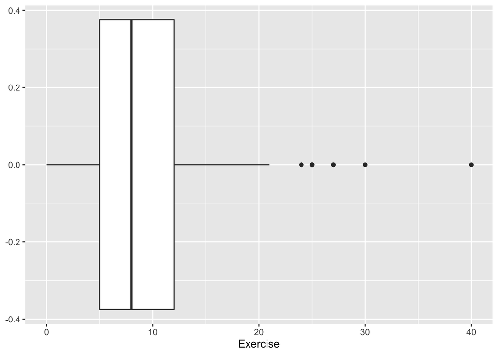

```r
ggplot(StudentSurvey, aes(y = Exercise)) +
  geom_boxplot() +
  coord_flip()
```

There are several outliers here, which could make later analyses tricky. What if we try grouping each person into a category? Something like “Little”, “Some”, “Moderate”, “High”, or “Extremely high” amounts of exercise?

We can do this, using the case_when() function. This lets us create new variables (with mutate()), when certain criteria (cases) occur. For example:

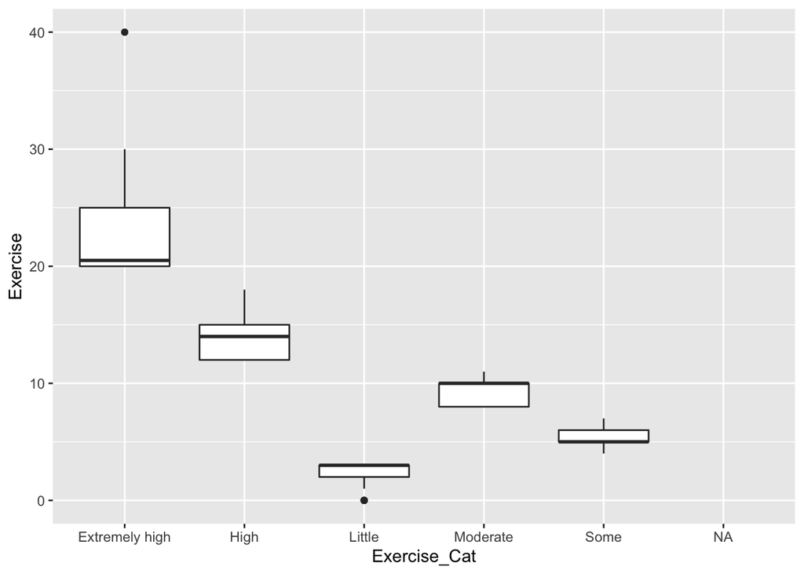

```r
StudentSurvey <- StudentSurvey %>%
  mutate(Exercise_Cat = case_when(
    Exercise >= 20 ~ "Extremely high",
    Exercise >= 12 ~ "High",
    Exercise >= 8 ~ "Moderate",
    Exercise >= 4 ~ "Some",
    Exercise < 4 ~ "Little"))

ggplot(StudentSurvey, aes(x = Exercise_Cat, y = Exercise)) +
  geom_boxplot()
```

That created a new variable called Exercise_Cat, with each student categorized by their exercise amount. However, our graph is confusing– R orders the categories alphabetically! We’d like to tell R the correct order for our categories.

## Change order of categories for categorical variable

We can use the function `fct_relevel()` to change the order of the categories for a categorical variable. This is considered data wrangling rather than data visualization, because it actually changes how R views our data set itself. After we change the order, the updated order will appear on ALL graphs, tables, models, etc.

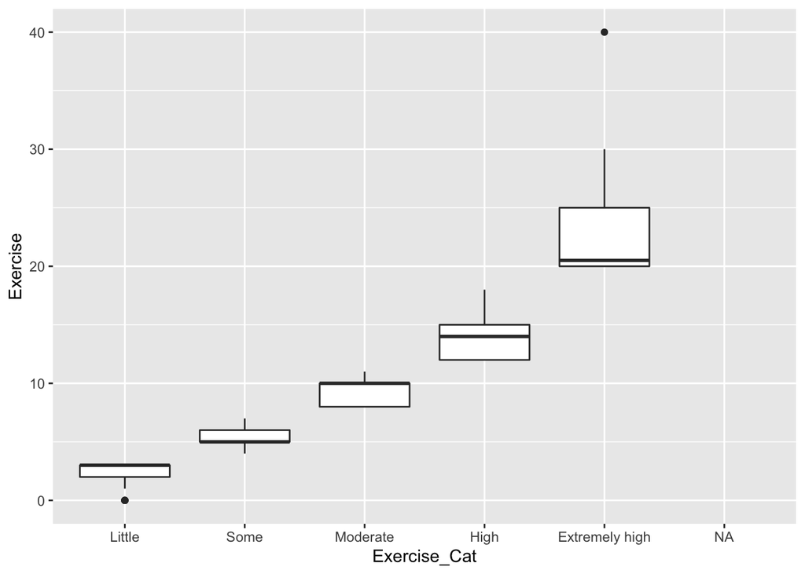

```r
# Reorder categories
ex_levels <- c("Little", "Some", "Moderate", "High", "Extremely high")

StudentSurvey <- StudentSurvey %>%
  mutate(Exercise_Cat = fct_relevel(Exercise_Cat, ex_levels))

ggplot(StudentSurvey, aes(x = Exercise_Cat, y = Exercise)) +
  geom_boxplot()
```

Much better!

From here, we can group by Exercise category and summarize other variables within each exercise category. Note again that R preserves the new order of the categories on all future tables, graphs, etc.:

```r
StudentSurvey %>%
  group_by(Exercise_Cat) %>%
  summarize(SAT_min = min(SAT, na.rm = TRUE),
            SAT_mean = mean(SAT, na.rm = TRUE),
            SAT_max = max(SAT, na.rm = TRUE),
            Num_students = n())
```

```
## # A tibble: 6 x 5
##   Exercise_Cat   SAT_min SAT_mean SAT_max Num_students
##   <fct>            <int>    <dbl>   <int>        <int>
## 1 Little             850    1209.    1540           61
## 2 Some               820    1202.    1550          106
## 3 Moderate           970    1210.    1530           74
## 4 High               800    1202.    1440           98
## 5 Extremely high    1010    1177.    1400           22
## 6 <NA>              1260    1260     1260            1
```